# IHSS Delphi Study Results

| Criterion | mean | std | p25 | p50 | p75 | max | IQR | QCD | Status |
| --- | --- | --- | --- | --- | --- | --- | --- | --- | --- |
| Cost-Effectiveness | 14.8 | 3.5 | 12.8 | 15.0 | 15.0 | 22.0 | 2.2 | 0.1 | Stable |
| Equity | 10.8 | 3.1 | 9.5 | 10.0 | 13.0 | 15.0 | 3.5 | 0.2 | Stable |
| Feasibility | 13.5 | 3.3 | 11.0 | 13.0 | 15.0 | 20.0 | 4.0 | 0.2 | Stable |
| Global priority | 8.5 | 3.0 | 5.5 | 8.0 | 11.0 | 12.5 | 5.5 | 0.3 | Slightly unstable |
| Health Impact | 16.6 | 4.2 | 13.5 | 17.0 | 19.0 | 25.0 | 5.5 | 0.2 | Slightly unstable |
| National priority | 12.0 | 1.8 | 10.0 | 12.0 | 13.2 | 15.0 | 3.2 | 0.1 | Stable |
| Risk | 7.9 | 3.8 | 5.0 | 5.0 | 11.0 | 15.0 | 6.0 | 0.4 | Slightly unstable |
| Sustainability | 16.0 | 3.2 | 13.2 | 16.0 | 19.0 | 20.0 | 5.8 | 0.2 | Slightly unstable |

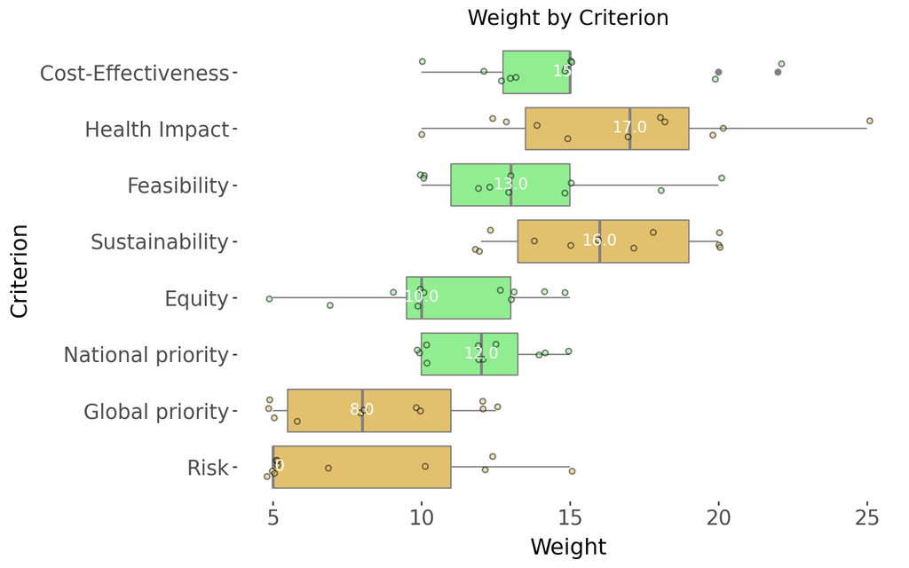

**Intervention Heatmap**

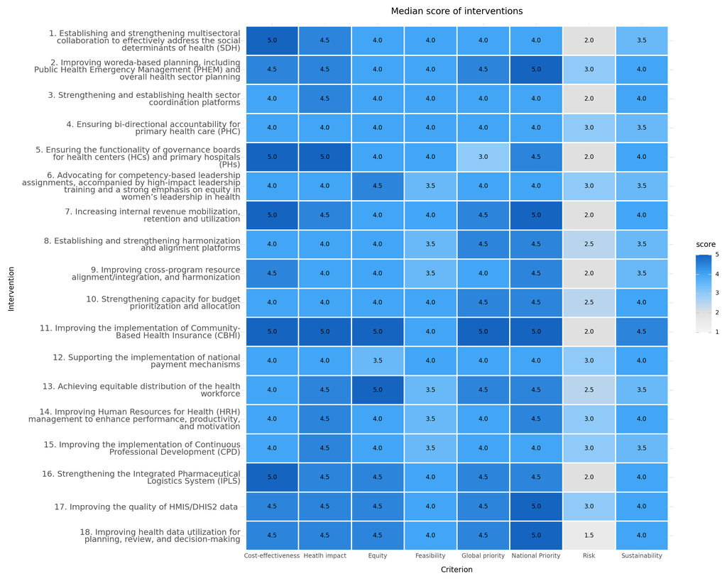

**Cost Effectiveness**

[figure not shown]

**Criterion weights summary**

Overall out of the 8 criteria, 4 (50.0%) are stable (IQR < 5). Details are provided below:

- **Experts gave similar scores (IQR < 5) for 4 (50.0%)** criteria: Cost-Effectiveness, Equity, Feasibility, National priority
- **Experts scores differ slightly (IQR between 5 and 10) for 4 (50.0%)** criteria: Global priority, Health Impact, Risk, Sustainability

#### Definition of terms

Various measures of central tendency and dispersion were used in the Delphi study to understand the “average” score and “expert consensus / dispersion” in the scores. Below are the various measures provided in the various tables, charts

##### Measures of central tendency

- **Mean**: It is the average of the scores provided and computed as the sum of the scores divided by the sample size. *Since the man is affected by outliers, we will use median as a key measure of central tendencey in this analysis*
- **Median**: It is the value that equally divides the expert opinions. 50% of the values are below and above the score. *The median is robust to outliers and is used as measure of central tendency*

##### Measures of dispersion / consensus

- **Standard deviation**: It is among the common measures of dispersion in data which is computed as $\sigma = \sqrt{\frac{1}{N} \sum_{i=1}^{N-1} (x_i - \mu)^2}$ whre x is the criterion or intervention being analyzed and N is the sample size. *Since the $\sigma$ is sensitive to outliers it is not used in assessing dispersion in this study.*
- **Interquartile range (IQR)**: It is a measure reperesnting the range between the first quartile (p25) and third quartile (p75) and shows the spread of the middle 50% of the data. It is computed as $IQR = Q3 - Q1$ where Q3 and Q1 are the 75% (i.e. 75% of the observations are below Q3) and 25% of the data (25% of obs below Q1). **IQR is used as primary measure of displersion in the study** The cutoffs are:
  - Cutoffs for criterion weight: **IQR < 5 : Stable** (consensus among experts), **5 > IQR < 10: Slightly unstable** (minor difference among experts), **IQR > 10: Unstable** (significant difference among experts)
  - Cutoffs for intervention scores (IQR is expected to be bn 1 and 4): **IQR < 1: Stable** (consensus among experts), **1 > IQR < 2**: Slightly unstable (minor difference among experts), ** IQR > 2: Unstable** (significant difference among experts)
- **Rescaled median absolute deviation (RMAD)**: It is a rescaled (0 to 1) of the median absolute deviation which is relatively more robust to outliers and data scale thatn IQR. IT is computed as $RMAD = median(|x_i - median(x_i)|) / ((b - a)/2)$ where a, b are the theoretical min and max of the variables. For criterion weights the min and max are assumed to be 5 and 35 while for intervetnion weighting the min and max are 1 and 5 respectively. The RMAD will be used as secondary measure of dispersion with the following cutoffs: **RMAD < 0.25 : Stable** (consensus among experts), **0.25 > RMAD < 0.5: Slightly unstable** (minor difference among experts), **RMAD > 0.5: Unstable** (significant difference among experts)